# Results

Kang

## 描述性结果

每日每十万用户发文数图如下。每日每万用户发文数 = 每日推文总数 / 当年用户总数。

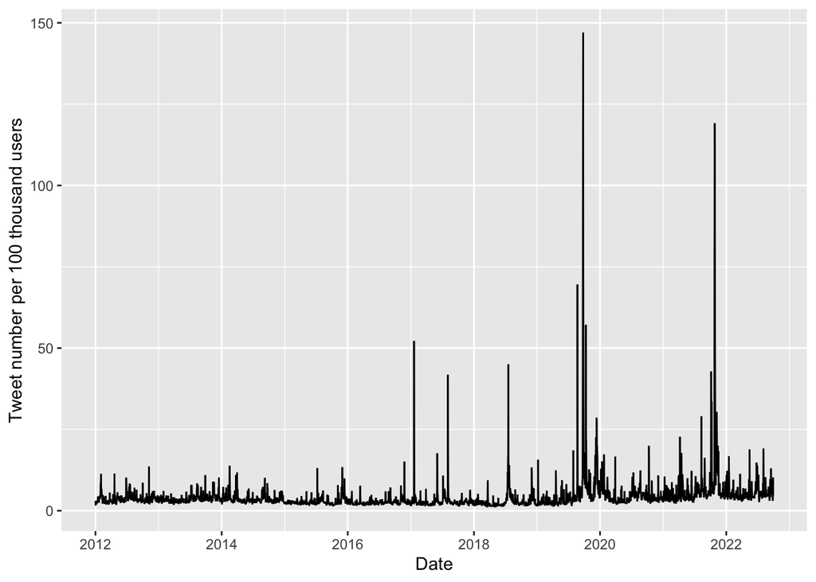

```r
tar_load(general_plot_dt)
ggplot(general_plot_dt) +
  geom_line(aes(date, tw_int)) +
  labs(x = "Date", y = "Tweet number per 100 thousand users")
```

## 峰值事件识别

（2）大于该高值线的日期称为高值日期。

（3）若高值日期连续天数大于等于3天，则称为一个事件。

分析结果和原本相同，原因是判断高值日期的标准是分位数，分位数原本的基于每年子数据集中的每日推文总数计算的，而现在是基于每年子数据集中的每日推文强度计算的。每日推文强度的计算方法，如上文所说，是每天推文数除以当年用户总数，而对于每个年份的子数据集，只有一个”当年用户总数”。所以虽然分位数的绝对值变化了，越过高值线的日期却不会变化。

取90分位数的情况，峰值事件如下。

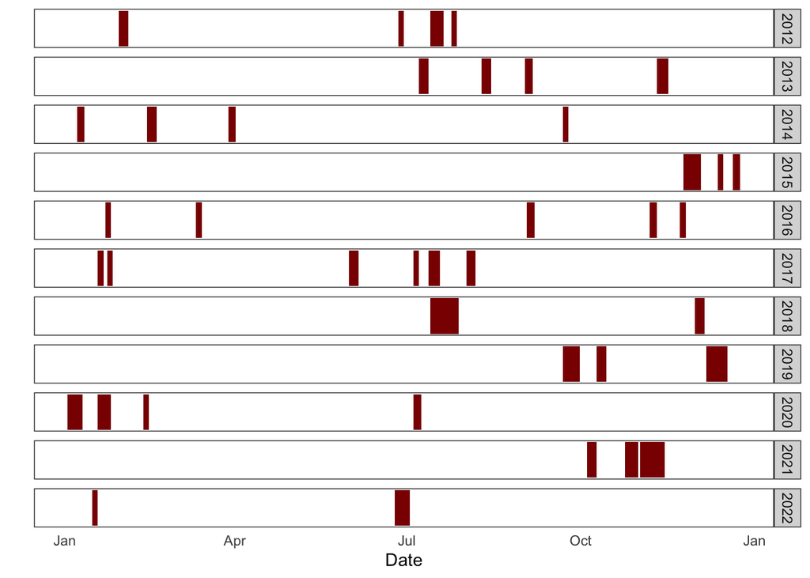

```r
tw_high_90 %>%
  mutate(
    day = day(date),
    date_dummy = as.Date(paste("9999", month, day, sep = "-"))
  ) %>%
  ggplot() +
  geom_tile(aes(date_dummy, 1), fill = "darkred") +
  theme_bw() +
  theme(
    axis.ticks.x = element_blank(),
    axis.ticks.y = element_blank(),
    axis.text.y = element_blank(),
    panel.grid = element_blank()
  ) +
  scale_x_date(date_labels = "%b") +
  labs(x = "Date", y = "") +
  facet_wrap(.~ year, ncol = 1, strip.position = "right")
```

```r
tw_high_90 %>%
  select(year, grp) %>%
  distinct() %>%
  group_by(year) %>%
  summarise(peak_num = n()) %>%
  ungroup() %>%
  knitr::kable()
```

| year | peak_num |
| --- | --- |
| 2012 | 4 |
| 2013 | 4 |
| 2014 | 4 |
| 2015 | 3 |
| 2016 | 5 |
| 2017 | 6 |
| 2018 | 2 |
| 2019 | 3 |
| 2020 | 4 |
| 2021 | 3 |
| 2022 | 2 |

取85分位数的情况，峰值事件如下。

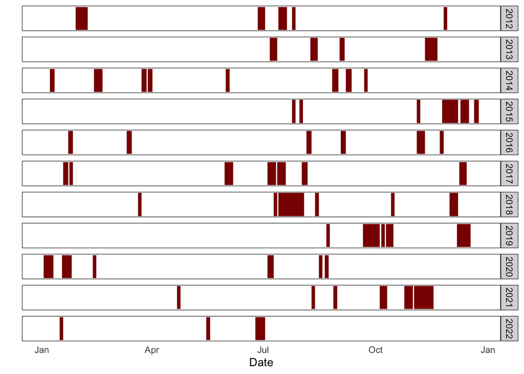

```r
tw_high_85 %>%
  mutate(
    day = day(date),
    date_dummy = as.Date(paste("9999", month, day, sep = "-"))
  ) %>%
  ggplot() +
  geom_tile(aes(date_dummy, 1), fill = "darkred") +
  theme_bw() +
  theme(
    axis.ticks.x = element_blank(),
    axis.ticks.y = element_blank(),
    axis.text.y = element_blank(),
    panel.grid = element_blank()
  ) +
  scale_x_date(date_labels = "%b") +
  labs(x = "Date", y = "") +
  facet_wrap(.~ year, ncol = 1, strip.position = "right")
```

```r
tw_high_85 %>%
  select(year, grp) %>%
  distinct() %>%
  group_by(year) %>%
  summarise(peak_num = n()) %>%
  ungroup() %>%
  knitr::kable()
```

| year | peak_num |
| --- | --- |
| 2012 | 5 |
| 2013 | 4 |
| 2014 | 8 |
| 2015 | 6 |
| 2016 | 6 |
| 2017 | 7 |
| 2018 | 6 |
| 2019 | 5 |
| 2020 | 6 |
| 2021 | 6 |
| 2022 | 3 |

## 峰值事件分析

分析对象是两个事件：“大米”（rice），“酷暑”（hot）。首先计算了两个事件中所有用户的（节点）的中心度，包括度量中心度（Degree centrality）、中介中心度（Betweenness centrality）。中心度计算以被转推者为核心，比如说一个用户被10个人转推了，那么它的度量中心度就是10。

其中，大米事件的前10位度量中心度高值用户如下。

```r
graph_cen[["rice"]] %>%
  arrange(-cen_degree) %>%
  select(retweeted_userid = name, retweeted_username = author_username, cen_degree) %>%
  head(10) %>%
  knitr::kable()
```

| retweeted_userid | retweeted_username | cen_degree |
| --- | --- | --- |
| 1161797133424455680 | NA | 10568 |
| 188620283 | ozawa_jimusho | 6722 |
| 249603227 | NA | 5618 |
| 94513095 | hiranok | 4327 |
| 1161186227279654912 | NA | 3667 |
| 1183178208398602240 | nipponkairagi | 3562 |
| 234201183 | NA | 3239 |
| 543860205 | HuffPostJapan | 3041 |
| 143328179 | hoku_mai | 2886 |
| 64695621 | Kitsch_Matsuo | 2869 |

大米事件中介中心度前10位如下。

```r
graph_cen[["rice"]] %>%
  arrange(-cen_between) %>%
  select(retweeted_userid = name, retweeted_username = author_username, cen_between) %>%
  head(10) %>%
  knitr::kable()
```

| retweeted_userid | retweeted_username | cen_between |
| --- | --- | --- |
| 2250342156 | yadanetnagano | 7634348 |
| 167832583 | kouzai2007 | 5949702 |
| 1239539301181870080 | ripplemark733 | 5931358 |
| 746436258 | OkadaAim990 | 5776206 |
| 2912822551 | jcpshonan1922 | 5752668 |
| 7323692 | CSambo | 4968662 |
| 64695621 | Kitsch_Matsuo | 4955695 |
| 69008611 | oricquen | 3851891 |
| 1515786181 | IkedaKiyohiko | 3605948 |
| 1268413900745175040 | qoib08EbfZXR4cY | 3587894 |

酷暑事件度量中心度前10位如下。

```r
graph_cen[["hot"]] %>%
  arrange(-cen_degree) %>%
  select(retweeted_userid = name, retweeted_username = author_username, cen_degree) %>%
  head(10) %>%
  knitr::kable()
```

| retweeted_userid | retweeted_username | cen_degree |
| --- | --- | --- |
| 87656713 | NA | 3758 |
| 822750195645485057 | amasehimika147 | 2464 |
| 121500765 | DrTomabechi | 1648 |
| 776651743077675008 | rainbow_309_204 | 643 |
| 1473097608206106626 | NA | 598 |
| 1514223953639718913 | mewmew_344 | 545 |
| 772049555164499968 | Beyond_Climate | 514 |
| 4620919093 | NA | 471 |
| 33464495 | NA | 392 |
| 1526335053898231808 | NA | 381 |

酷暑事件中介中心度前10位如下。

```r
graph_cen[["hot"]] %>%
  arrange(-cen_between) %>%
  select(retweeted_userid = name, retweeted_username = author_username, cen_between) %>%
  head(10) %>%
  knitr::kable()
```

| retweeted_userid | retweeted_username | cen_between |
| --- | --- | --- |
| 822750195645485057 | amasehimika147 | 10237.923 |
| 955818757892448256 | nnyrG6mn5UqyPy1 | 6251.327 |
| 1031205553911939073 | a57454412 | 3961.657 |
| 708305398793547776 | lililily_moon | 3283.414 |
| 3945279974 | sally38622573 | 2078.445 |
| 1514223953639718913 | mewmew_344 | 1885.074 |
| 776651743077675008 | rainbow_309_204 | 1868.262 |
| 1358220296625418240 | o1ZBoSwhXrk51dP | 1279.521 |
| 4712075358 | ohanachan28 | 1120.665 |
| 157300022 | takayan309 | 1048.872 |

然后做网络图。由于无法将所有的节点和连接都画出来（非常耗时而且看不清联系），筛选出度量中心度或中介中心度比较高的节点做网络图。community detection采用的方法是"connected compenents using [igraph::components()](http://127.0.0.1:33663/help/library/igraph/help/components)"，因为group_louvain()只能用来做无方向连接网络的community detection。两个事件的网络图如下，community以颜色区分，并且展示中心用户在网络中的位置，标签为账户名（就是艾特后面那串）。对于数据库中无对应账户名的，以空标签框表示。

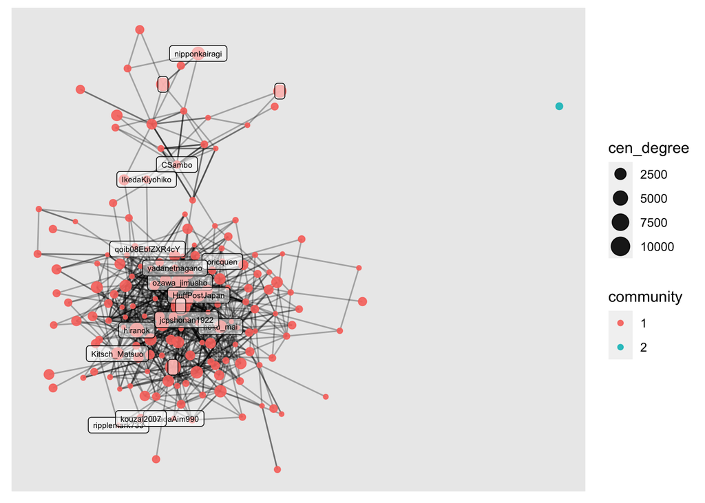

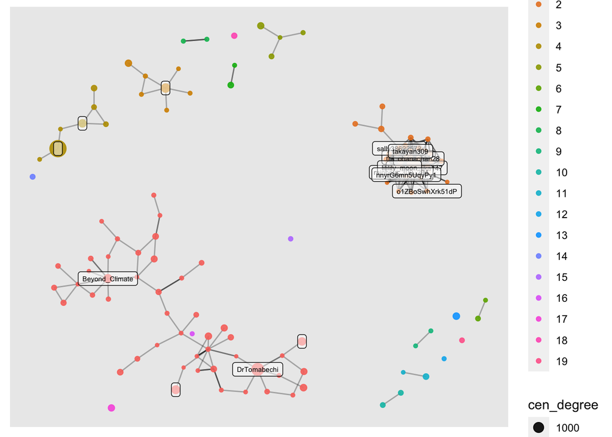

```r
net_plot_comm
```

为了方便识别这些中心节点都是些什么用户，随报告附上各个中心节点对应的源头用户相关资料，包括用户的ID、账户名、账户描述、发过的被广为传播的推文内容。